# Assignment5

# Data Cleaning

## Data Summary

```r
housing <- read.csv("housing.csv", stringsAsFactors=T)
summary(housing)
```

```
       Id           MSSubClass       MSZoning
 Min.   :   1.0   Min.   : 20.0   C (all):  10
 1st Qu.: 365.8   1st Qu.: 20.0   FV     :  65
 Median : 730.5   Median : 50.0   RH     :  16
 Mean   : 730.5   Mean   : 56.9   RL     :1151
 3rd Qu.:1095.2   3rd Qu.: 70.0   RM     : 218
 Max.   :1460.0   Max.   :190.0

  LotFrontage        LotArea        Street
 Min.   : 21.00   Min.   :  1300   Grvl:   6
 1st Qu.: 59.00   1st Qu.:  7554   Pave:1454
 Median : 69.00   Median :  9478
 Mean   : 70.05   Mean   : 10517
 3rd Qu.: 80.00   3rd Qu.: 11602
 Max.   :313.00   Max.   :215245
 NA's   :259
  Alley      LotShape  LandContour  Utilities
 Grvl:  50   IR1:484   Bnk:  63    AllPub:1459
 Pave:  41   IR2: 41   HLS:  50    NoSeWa:   1
 NA's:1369   IR3: 10   Low:  36
             Reg:925   Lvl:1311



   LotConfig    LandSlope   Neighborhood   Condition1
 Corner : 263   Gtl:1382   NAmes  :225   Norm   :1260
 CulDSac:  94   Mod:  65   CollgCr:150   Feedr  :  81
 FR2    :  47   Sev:  13   OldTown:113   Artery :  48
 FR3    :   4              Edwards:100   RRAn   :  26
 Inside :1052              Somerst: 86   PosN   :  19
                           Gilbert: 79   RRAe   :  11
                           (Other):707   (Other):  15
   Condition2     BldgType      HouseStyle
 Norm   :1445   1Fam  :1220   1Story :726
 Feedr  :   6   2fmCon:  31   2Story :445
 Artery :   2   Duplex:  52   1.5Fin :154
 PosN   :   2   Twnhs :  43   SLvl   : 65
 RRNn   :   2   TwnhsE: 114   SFoyer : 37
 PosA   :   1                 1.5Unf : 14
 (Other):   2                 (Other): 19
```

[output cut: 145 more lines]

```
 Min.   :    0.00   Min.   : 1.000   Min.   :2006
 1st Qu.:    0.00   1st Qu.: 5.000   1st Qu.:2007
 Median :    0.00   Median : 6.000   Median :2008
 Mean   :   43.49   Mean   : 6.322   Mean   :2008
 3rd Qu.:    0.00   3rd Qu.: 8.000   3rd Qu.:2009
 Max.   :15500.00   Max.   :12.000   Max.   :2010

    SaleType    SaleCondition    SalePrice
 WD     :1267   Abnorml: 101   Min.   : 34900
 New    : 122   AdjLand:   4   1st Qu.:129975
 COD    :  43   Alloca :  12   Median :163000
 ConLD  :   9   Family :  20   Mean   :180921
 ConLI  :   5   Normal :1198   3rd Qu.:214000
 ConLw  :   5   Partial: 125   Max.   :755000
 (Other):   9
```

```r
str(housing)
```

```
'data.frame':   1460 obs. of  81 variables:
 $ Id           : int  1 2 3 4 5 6 7 8 9 10 ...
 $ MSSubClass   : int  60 20 60 70 60 50 20 60 50 190 ...
 $ MSZoning     : Factor w/ 5 levels "C (all)","FV",..: 4 4 4 4 4 4 4 4 5 4 ...
 $ LotFrontage  : int  65 80 68 60 84 85 75 NA 51 50 ...
 $ LotArea      : int  8450 9600 11250 9550 14260 14115 10084 10382 6120 7420 ...
 $ Street       : Factor w/ 2 levels "Grvl","Pave": 2 2 2 2 2 2 2 2 2 2 ...
 $ Alley        : Factor w/ 2 levels "Grvl","Pave": NA NA NA NA NA NA NA NA NA NA ...
 $ LotShape     : Factor w/ 4 levels "IR1","IR2","IR3",..: 4 4 1 1 1 1 4 1 4 4 ...
 $ LandContour  : Factor w/ 4 levels "Bnk","HLS","Low",..: 4 4 4 4 4 4 4 4 4 4 ...
 $ Utilities    : Factor w/ 2 levels "AllPub","NoSeWa": 1 1 1 1 1 1 1 1 1 1 ...
 $ LotConfig    : Factor w/ 5 levels "Corner","CulDSac",..: 5 3 5 1 3 5 5 1 5 1 ...
 $ LandSlope    : Factor w/ 3 levels "Gtl","Mod","Sev": 1 1 1 1 1 1 1 1 1 1 ...
 $ Neighborhood : Factor w/ 25 levels "Blmngtn","Blueste",..: 6 25 6 7 14 12 21 17 18 4 ...
 $ Condition1   : Factor w/ 9 levels "Artery","Feedr",..: 3 2 3 3 3 3 3 5 1 1 ...
```

[output cut: 67 more lines]

### Variable Types

- Id: Continuous
- MSSubClass: Nominal Categorical (represented numerically)
- MSZoning: Nominal Categorical
- LotFrontage: Continuous
- LotArea: Continuous
- Street: Nominal Categorical
- Alley: Nominal Categorical
- LotShape: Nominal Categorical
- LandContour: Nominal Categorical
- Utilities: Nominal Categorical
- LotConfig: Nominal Categorical
- LandSlope: Nominal Categorical
- Neighborhood: Nominal Categorical
- Condition1: Nominal Categorical
- Condition2: Nominal Categorical
- BldgType: Nominal Categorical
- HouseStyle: Nominal Categorical
- OverallQual: Discrete Ordinal
- OverallCond: Discrete Ordinal
- YearBuilt: Continuous
- YearRemodAdd: Continuous
- RoofStyle: Nominal Categorical
- RoofMatl: Nominal Categorical
- Exterior1st: Nominal Categorical
- Exterior2nd: Nominal Categorical
- MasVnrType: Nominal Categorical
- MasVnrArea: Continuous
- ExterQual: Discrete Ordinal
- ExterCond: Discrete Ordinal
- Foundation: Nominal Categorical
- BsmtQual: Discrete Ordinal
- BsmtCond: Discrete Ordinal
- BsmtExposure: Discrete Ordinal
- BsmtFinType1: Discrete Ordinal
- BsmtFinSF1: Continuous
- BsmtFinType2: Discrete Ordinal
- BsmtFinSF2: Continuous
- BsmtUnfSF: Continuous
- TotalBsmtSF: Continuous
- Heating: Nominal Categorical
- HeatingQC: Discrete Ordinal
- CentralAir: Nominal Categorical
- Electrical: Nominal Categorical
- X1stFlrSF: Continuous
- X2ndFlrSF: Continuous
- LowQualFinSF: Continuous
- GrLivArea: Continuous
- BsmtFullBath: Continuous
- BsmtHalfBath: Continuous
- FullBath: Continuous
- HalfBath: Continuous
- BedroomAbvGr: Continuous
- KitchenAbvGr: Continuous
- KitchenQual: Discrete Ordinal
- TotRmsAbvGrd: Continuous
- Functional: Discrete Ordinal
- Fireplaces: Continuous
- FireplaceQu: Discrete Ordinal
- GarageType: Nominal Categorical
- GarageYrBlt: Continuous
- GarageFinish: Discrete Ordinal
- GarageCars: Continuous
- GarageArea: Continuous
- GarageQual: Discrete Ordinal
- GarageCond: Discrete Ordinal
- PavedDrive: Discrete Ordinal
- WoodDeckSF: Continuous
- OpenPorchSF: Continuous
- EnclosedPorch: Continuous
- X3SsnPorch: Continuous
- ScreenPorch: Continuous
- PoolArea: Continuous
- PoolQC: Discrete Ordinal
- Fence: Discrete Ordinal
- MiscFeature: Nominal Categorical
- MiscVal: Continuous
- MoSold: Nominal Categorical
- YrSold: Continuous
- SaleType: Nominal Categorical
- SaleCondition: Nominal Categorical
- SalePrice: Continuous

### NA Values

The following columns contain NA values, each with the corresponding percentage:

```r
i <- 1
while(i <= ncol(housing)){
  if(sum(is.na(housing[,i])) > 0){
    print(sprintf("%-15s%f%s", paste(colnames(housing)[i], ":", sep=""), length(which(is.na(housing[,i]))) / nrow(housing) * 100, "%"))
  }
  i <- i + 1
}
```

```
[1] "LotFrontage:   17.739726%"
[1] "Alley:         93.767123%"
[1] "MasVnrType:    0.547945%"
[1] "MasVnrArea:    0.547945%"
[1] "BsmtQual:      2.534247%"
[1] "BsmtCond:      2.534247%"
[1] "BsmtExposure:  2.602740%"
[1] "BsmtFinType1:  2.534247%"
[1] "BsmtFinType2:  2.602740%"
[1] "Electrical:    0.068493%"
[1] "FireplaceQu:   47.260274%"
[1] "GarageType:    5.547945%"
[1] "GarageYrBlt:   5.547945%"
[1] "GarageFinish:  5.547945%"
[1] "GarageQual:    5.547945%"
[1] "GarageCond:    5.547945%"
[1] "PoolQC:        99.520548%"
[1] "Fence:         80.753425%"
[1] "MiscFeature:   96.301370%"
```

### Replace NA Values

```r
replaceNumericNA <- function(column){
  if(is.numeric(column))
    column[which(is.na(column))] <- 0
  return(column)
}
replaceFactorNA <- function(column){
  if(is.numeric(column) || sum(is.na(column)) == 0){
    return(column)
  }
  facna <- addNA(column)
  levels(facna) <- c(levels(column), "None")
  return(facna)
}
housing.no_na <- housing
electrical <- housing$Electrical # Electrical does not have a valid NA factor
housing.no_na <- as.data.frame(lapply(housing.no_na, replaceNumericNA))
housing.no_na <- as.data.frame(lapply(housing.no_na, replaceFactorNA))
housing.no_na$Electrical <- electrical
```

The only column that is actually missing any values is Electrical, and it is missing 1 row(s), making up 0.0684932% of the data.

Since Electrical is the only column with any remaining NA values, the percentage of missing Electrical rows is the same as the percentage of missing rows in the entire dataset.

# Data Exploration

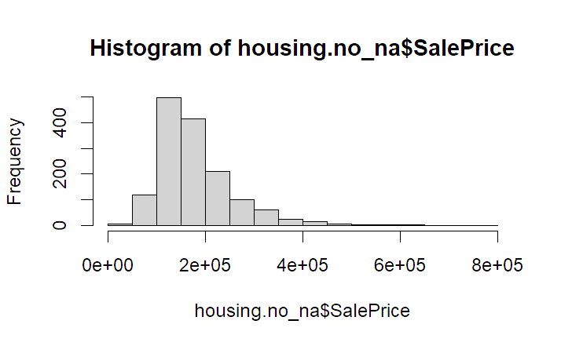

```r
hist(housing.no_na$SalePrice)
```

The data are positively skewed.

```r
# setup
library(gmodels)
library(vcd)
```

```
[1] "Spearman Rank Test: Sale Price by Id -0.0185456245359775"
```

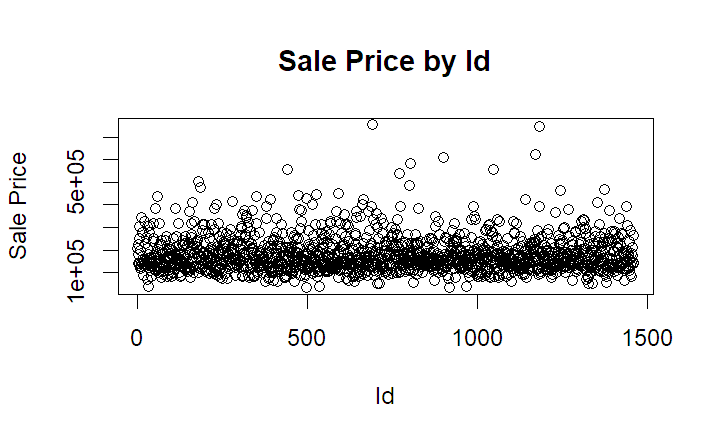

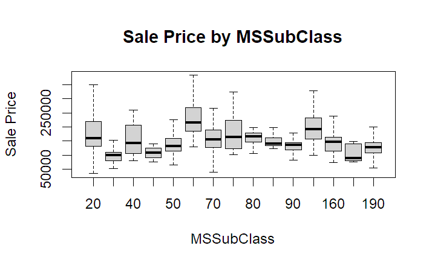

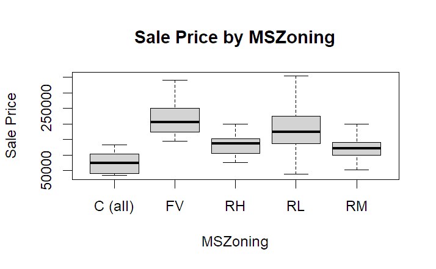

```
[1] "Spearman Rank Test: Sale Price by LotFrontage 0.238496112979082"
```

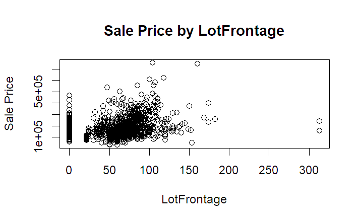

```
[1] "Spearman Rank Test: Sale Price by LotArea 0.456460583391211"
```

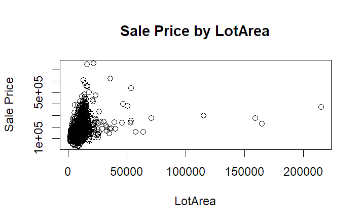

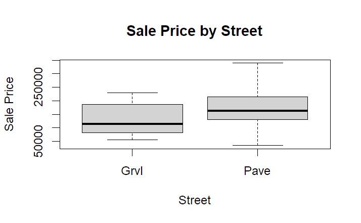

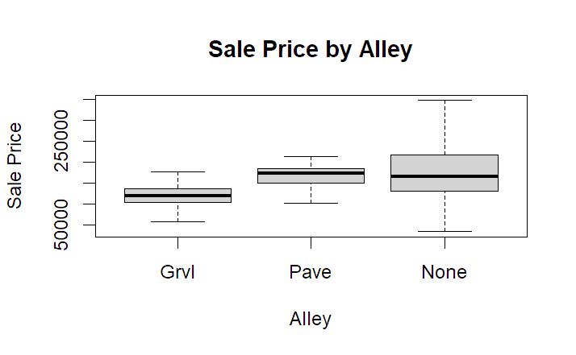

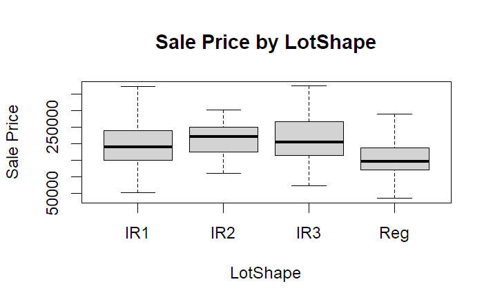

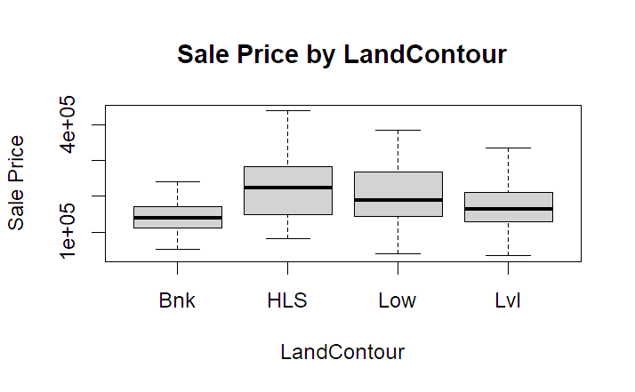

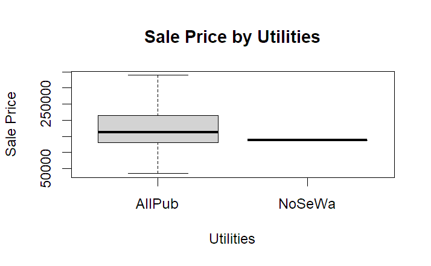

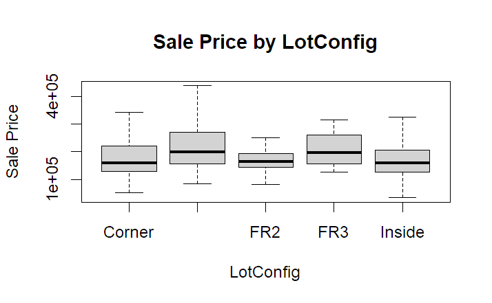

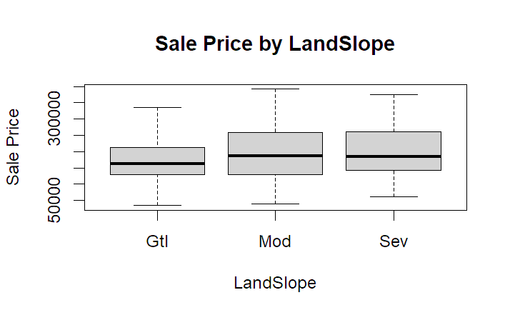

[49 more figures not shown]

```r
# for each column in the bank dataset, determine the classification of the data by referring to the cat vector and run the appropriate test based on that value
i <- 1
data <- housing.no_na
salePrice <- housing.no_na$SalePrice
while(i < length(cat)){
  otherC <- data[,i]
  otherN <- colnames(data[i])
  if(cat[i] == c ){
    plot(salePrice~otherC, main = paste("Sale Price by", otherN), xlab = otherN, ylab = "Sale Price")
    print(paste("Spearman Rank Test: Sale Price by", otherN, cor(y=salePrice, x=otherC, method="spearman", use="pairwise.complete.obs")))
  }else if(cat[i] == o){
    print(paste("Wilcoxon Rank Sum Test: Sale Price by", otherN))
    print(wilcox.test(y=salePrice, x=as.numeric(otherC)))
  }else if(cat[i] == n){
    boxplot(salePrice~otherC, main = paste("Sale Price by", otherN), xlab = otherN, ylab = "Sale Price", outline=F)
  }
  i <- i + 1
}
```

## Remove Weak Association Columns

```r
housing.removed <- housing.no_na
housing.removed$Id <- NULL
housing.removed$LotFrontage <- NULL
housing.removed$LotArea <- NULL
housing.removed$LandSlope <- NULL
housing.removed$MasVnrArea <- NULL
housing.removed$BsmtFinSF1 <- NULL
housing.removed$BsmtFinSF2 <- NULL
housing.removed$BsmtUnfSF <- NULL
housing.removed$TotalBsmtSF <- NULL
housing.removed$X2ndFlrSF <- NULL
housing.removed$LowQualFinSF <- NULL
housing.removed$BsmtFullBath <- NULL
housing.removed$BsmtHalfBath <- NULL
housing.removed$HalfBath <- NULL
housing.removed$BedroomAbvGr <- NULL
housing.removed$KitchenAbvGr <- NULL
housing.removed$WoodDeckSF <- NULL
housing.removed$OpenPorchSF <- NULL
housing.removed$EnclosedPorch <- NULL
housing.removed$X3SsnPorch <- NULL
housing.removed$ScreenPorch <- NULL
housing.removed$PoolArea <- NULL
housing.removed$MiscVal <- NULL
housing.removed$MoSold <- NULL
housing.removed$YrSold <- NULL
housing.removed$MSSubClass <- as.factor(housing.removed$MSSubClass) # Convert to categorical variable
```

## Remove NA Value

Because only one row has a missing value, we can safely remove the row without affecting the integrity of the data.

```r
housing.removeNA <- na.omit(housing.removed)
```

# Creating Predictive Models

## Partition Data

```r
library(caret)
set.seed(1)
train_and_val_idx <- createDataPartition(housing.removeNA$MSSubClass, p = 0.8, list = F)
housing.train_and_val <- housing.removeNA[train_and_val_idx,]
housing.test <- housing.removeNA[-train_and_val_idx,]

train <- createDataPartition(housing.train_and_val$MSSubClass, p = 0.9, list = F)
housing.train <- housing.train_and_val[train,]
housing.val <- housing.train_and_val[-train,]

salePriceIndex <- ncol(housing.train)
train.data <- housing.train[,-salePriceIndex]
train.labels <- housing.train[,salePriceIndex]

val.data <- housing.val[,-salePriceIndex]
val.labels <- housing.val[,salePriceIndex]

test.data <- housing.test[,-salePriceIndex]
test.labels <- housing.test[,salePriceIndex]
```

## Lasso

### Train Model

```r
library(glmnet)

set.seed(1)
lasso <- train(
  SalePrice~.,
  data = housing.train_and_val,
  method="glmnet",
  preProc="nzv",
  trControl = trainControl("cv", number=10),
  tuneGrid = expand.grid(
    alpha = 1,
    lambda = 10^seq(-3, 3, length = 100)
    )
  )
```

### Coefficients

```r
coef(lasso$finalModel, lasso$bestTune$lambda)
```

[output not shown]

Many of the columns were shrunk down to 0, meaning they had too little significance in the grand scheme of the model. Since LASSO seeks to penalize large coefficients, it will shrink all coefficients to maintain the model’s integrity and thus will shrink down some coefficients to 0.

### Predict

```r
predictions <- predict(lasso, test.data)
rmse.vals["lasso"] <- RMSE(predictions, test.labels)
rmse.vals["lasso"]
```

## Ridge

### Train Model

```r
set.seed(1)
ridge <- train(
  SalePrice~.,
  data = housing.train_and_val,
  method="glmnet",
  preProc="nzv",
  trControl = trainControl("cv", number=10),
  tuneGrid = expand.grid(
    alpha = 0,
    lambda = 10^seq(-3, 3, length = 100)
    )
  )
```

### Coefficients

```r
coef(ridge$finalModel, ridge$bestTune$lambda)
```

[output not shown]

### Predict

```r
predictions <- predict(ridge, test.data)
rmse.vals["ridge"] <- RMSE(predictions, test.labels)
rmse.vals["ridge"]
```

```
$ridge
[1] 33474.29
```

## Elastic Net

### Train Model

```r
library(glmnet)

set.seed(1)
elastic.net <- train(
  SalePrice~.,
  data = housing.train_and_val,
  method="glmnet",
  preProc="nzv",
  trControl = trainControl("cv", number=10),
  tuneGrid = expand.grid(
    alpha = seq(0, 1, length = 10),
    lambda = 10^seq(-3, 3, length = 100)
    )
  )
```

### Coefficients

```r
coef(elastic.net$finalModel, elastic.net$bestTune$lambda)
```

[output not shown]

### Predict

```r
predictions <- predict(elastic.net, test.data)
rmse.vals["elastic net"] <- RMSE(predictions, test.labels)
rmse.vals["elastic net"]
```

# Creating Tree-Ensemble and SVM Models

## Random Forest

### Train Model

```r
set.seed(1)
random.forest <- train(
  SalePrice~.,
  data = housing.train_and_val,
  method="rf",
  preProc="nzv",
  trControl = trainControl("cv", number=10),
  tuneGrid = expand.grid(
    mtry = c(2, 4, 8, 16)
    ),
  importance=T
  )
```

### Predict

```r
predictions <- predict(random.forest, test.data)
rmse.vals["random forest"] <- RMSE(predictions, test.labels)
rmse.vals["random forest"]
```

### Variable Importance

```r
varImp(random.forest, scale=F)
```

[output not shown]

- GrLivArea
- X1stFlrSF
- OverallQual
- GarageArea
- GarageCars

## Gradient Boosted Tree

### Train Model

```r
set.seed(1)
gbm.tree <- train(
  SalePrice~.,
  data = housing.train_and_val,
  method="gbm",
  preProc="nzv",
  trControl = trainControl("cv", number=10)
  )
```

### Predict

```r
predictions <- predict(gbm.tree, test.data)
rmse.vals["gbm tree"] <- RMSE(predictions, test.labels)
rmse.vals["gbm tree"]
```

## Linear Support Vector Machine Model

### Train Model

```r
set.seed(1)

svm <- train(
  SalePrice~.,
  data = housing.train_and_val,
  method="svmLinear",
  preProc=c("nzv", "knnImpute"),
  trControl = trainControl("cv", number=10),
  tuneGrid = expand.grid(
    C = seq(0.1, 2, by = 0.1)
    )
  )
```

In the SVM Linear model, the hyperparamter `C` stands for cost, which correlates to the penalty when the model misclassifies a data point, or in the case of regression, it’s the weight of the difference from the actual value.

### Predict

```r
predictions <- predict(svm, test.data)
rmse.vals["linear svm"] <- RMSE(predictions, test.labels)
rmse.vals["linear svm"]
```

## Radial Support Vector Machine Model

### Train Model

```r
set.seed(1)

r.svm <- train(
  SalePrice~.,
  data = housing.train_and_val,
  method="svmRadial",
  preProc=c("nzv", "knnImpute"),
  trControl = trainControl("cv", number=10),
  tuneGrid = expand.grid(
    C = seq(0.1, 2, by = 0.1)
    ,sigma = seq(0.1, 2, by = 0.1)
    )
  )
```

### Predict

```r
predictions <- predict(r.svm, test.data)
rmse.vals["radial svm"] <- RMSE(predictions, test.labels)
rmse.vals["radial svm"]
```

## Compare Models

### Create List of Models

```r
models <- list(lasso, ridge, elastic.net, random.forest, gbm.tree, svm, r.svm)
```

### Results

```r
comparisons <- resamples(models, modelNames = c("lasso", "ridge", "elastic net", "random forest", "gbm tree", "linear svm", "radial svm"))
summary(comparisons)
```

[output not shown]

# Creating a Neural Network Model

## Scale and Normalize Data

```r
preproc <- preProcess(train.data, method="knnImpute")

train.imputed <- predict(preproc, train.data)
val.imputed <- predict(preproc, val.data)
test.imputed <- predict(preproc, test.data)
```

## One-Hot Encode Categorical Values

```r
library(mltools)
library(data.table)
train.one_hot <- one_hot(as.data.table(train.imputed))
val.one_hot <- one_hot(as.data.table(val.imputed))
test.one_hot <- one_hot(as.data.table(test.imputed))
```

## Remove NearZeroVar Variables

```r
nzv <- nearZeroVar(train.one_hot)
train.nzv <- subset(train.one_hot, select= -c(nzv))
val.nzv <- subset(val.one_hot, select= -c(nzv))
test.nzv <- subset(test.one_hot, select= -c(nzv))
```

## Create Model

```r
library(keras)
library(tensorflow)

ann <- keras_model_sequential() %>%
  layer_dense(
     units = 32
    ,activation = "sigmoid"
    ,input_shape = ncol(train.nzv)
    ) %>%                          # input and first hidden layer
  layer_dense(
     units = 16
    ,activation = "sigmoid"
    ) %>%                          # second hidden layer
  layer_dense(
     units = 1
    ,activation = "relu"
    )                              # output layer

ann %>% compile(
  optimizer = 'adam',
  loss = 'mse',
  metrics = 'mae'
)
```

```r
val <- as.matrix(val.nzv)

set.seed(1)
tensorflow::set_random_seed(1)
history <- ann %>% fit(
   as.matrix(train.nzv)
  ,as.matrix(train.labels/100000)
  ,epochs = 100
  ,validation_data=list(val, val.labels/100000)
  ,batch_size = 64)
plot(history)
```

[output not shown]

## Predict

```r
ann %>% evaluate(as.matrix(test.nzv), as.matrix(test.labels/100000))
predictions <- ann %>% predict(as.matrix(test.nzv)) * 100000
rmse.vals["artificial neural network"] <- RMSE(predictions, test.labels)
rmse.vals["artificial neural network"]
```

## Tune Hyperparameters

```r
library(tfruns)
set.seed(1)
tensorflow::set_random_seed(1)
runs=tuning_run("housing_hyperparams.R",
            flags = list(
               learning_rate = c(0.1, 0.01, 0.001, 0.0001)
              ,batch_size = c(32,64,1)
              ,units1= c(16,32,64,128)
              ,units2= c(16,32,64,128)
              ,dropout1= c(0.1, 0.2, 0.3, 0.4)
              ,dropout2= c(0.1, 0.2, 0.3, 0.4)
            )
            ,sample = 0.01
 )
```

## Results

```r
print(runs)
```

### Best Model

```r
runs=runs[order(runs$metric_val_loss, decreasing=F),]
view_run(runs$run_dir[1])
```

[output not shown]

The best model used the following parameters:

## Train Best Model

```r
train_and_val.nzv <- rbind(train.nzv, val.nzv)
train_and_val.labels <- append(train.labels, val.labels)

best_ann <- keras_model_sequential() %>%
  layer_dense(
     units = 64
    ,activation = "sigmoid"
    ,input_shape = ncol(train_and_val.nzv)
    ) %>%                          # input and first hidden layer
  layer_dropout(0.1) %>%
  layer_dense(
     units = 32
    ,activation = "sigmoid"
    ) %>%                          # second hidden layer
  layer_dropout(0.4) %>%
  layer_dense(
     units = 1
    ,activation = "relu"
    )                              # output layer

best_ann %>% compile(
  optimizer = optimizer_adam(learning_rate=0.01),
  loss = 'mse',
  metrics = 'mae'
)

set.seed(1)
tensorflow::set_random_seed(1)
history <- best_ann %>% fit(
   as.matrix(train_and_val.nzv)
  ,as.matrix(train_and_val.labels/100000)
  ,epochs = 30
  ,batch_size = 64)
plot(history)
```

[output not shown]

## Predict

```r
best_ann %>% evaluate(as.matrix(test.nzv), as.matrix(test.labels/100000))
predictions <- best_ann %>% predict(as.matrix(test.nzv)) * 100000
rmse.vals["tuned neural network"] <- RMSE(predictions, test.labels)
rmse.vals["tuned neural network"]
```

# Results

## List of RMSE Values

```r
print(rmse.vals)
```

[output not shown]